# Day-02: GPA with Semilandmarks

## **Content Description**

Generalized Procrustes Analysis (GPA) is typically performed on sets of ‘fixed’ landmarks. However, the algorithm has been extended to allow one to incorporate sliding semilandmarks on curves and surfaces. Here we demonstrate this capability in `gpagen`:

## **Example 1: fixed points only**

```r
library(geomorph)
```

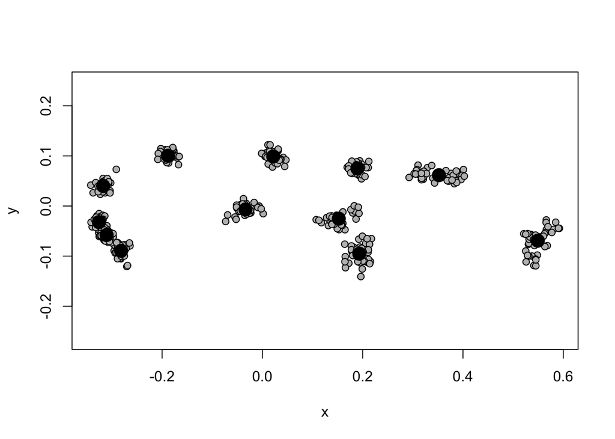

```r
data(plethodon)
pleth.gpa <- gpagen(plethodon$land, print.progress = F)

plot(pleth.gpa)
```

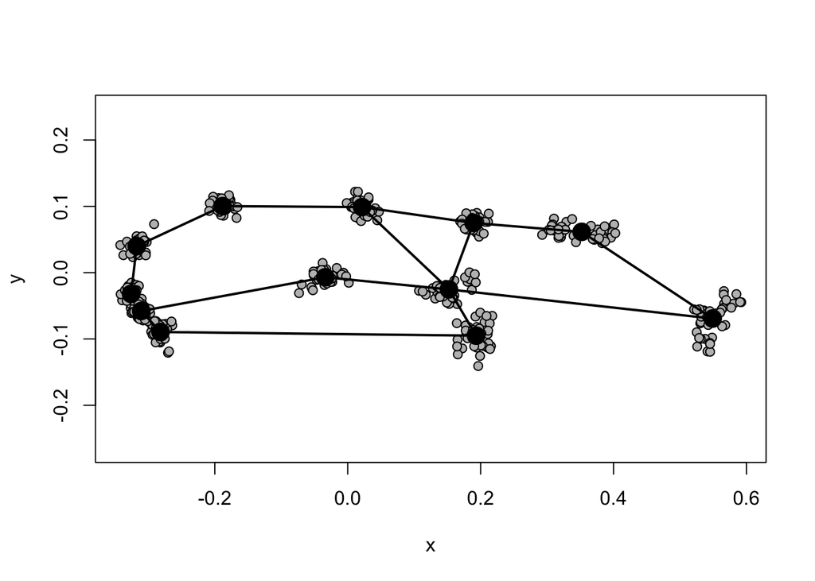

```r
plotAllSpecimens(pleth.gpa$coords, links = plethodon$links)
```

## **Example 2: Points and Semilandmarks on Curves**

Now let’s add some points on curves. To do so, one must provide `gpagen` with a matrix that specifies which landmarks should be treated as sliding semilandmarks. This information is found in the ‘sliders’ matrix, which is a $\small{m \times 3}$ matrix for $\small{m}$ sliding semilandmarks as described in lecture (NOTE: `StereoMorph` objects retain this information differently and it is provided automatically: **see below**). Here is an example of such a matrix:

```r
data(hummingbirds)
hummingbirds$curvepts
```

```
##       before slide after
##  [1,]      1    11    12
##  [2,]     11    12    13
##  [3,]     13    14    15
##  [4,]      7    15    14
##  [5,]     12    13    14
##  [6,]      1    16    17
##  [7,]     16    17    18
##  [8,]     17    18    19
##  [9,]     18    19    20
## [10,]     10    20    19
## [11,]      2    21    22
## [12,]     21    22    23
## [13,]     22    23    24
## [14,]     23    24    25
## [15,]      8    25    24
```

The function `gpagen` currently performs sliding in two ways: based on Bending Energy or based on Procrustes Distance. These may be implemented as follows:

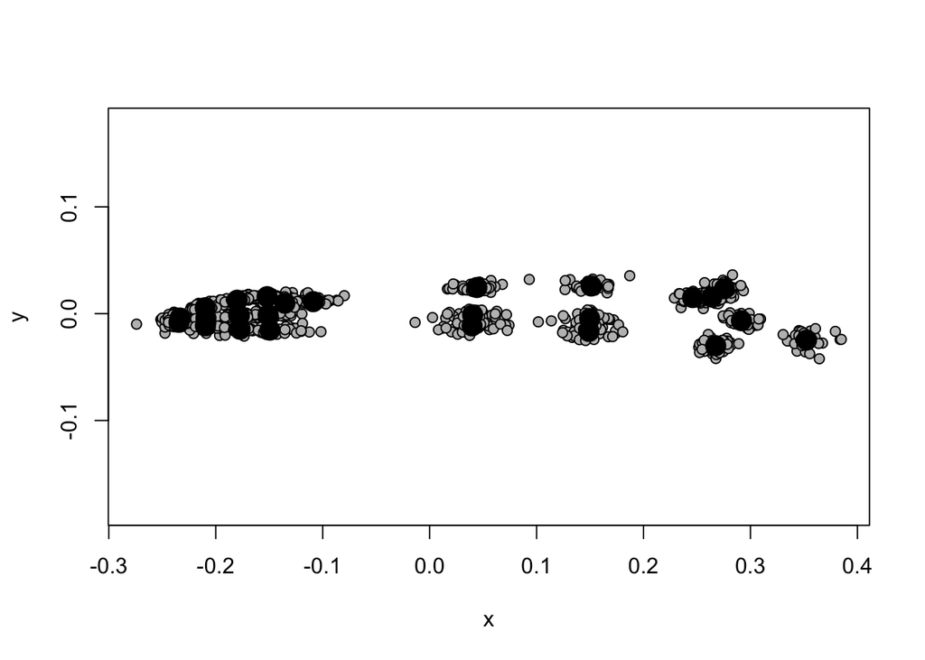

```r
gpa.BE <- gpagen(hummingbirds$land, curves=hummingbirds$curvepts, ProcD=FALSE, print.progress = F)
plot(gpa.BE)
```

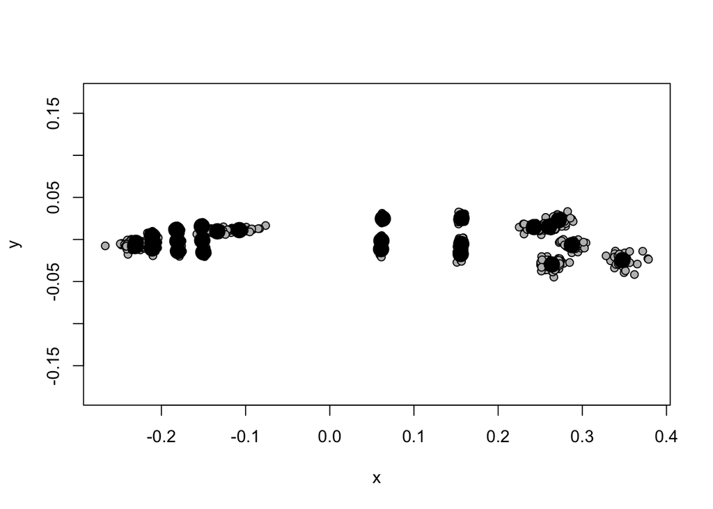

```r
gpa.procD <- gpagen(hummingbirds$land, curves=hummingbirds$curvepts, ProcD=TRUE, print.progress = F)
plot(gpa.procD)
```

#### Example using StereoMorph Objects

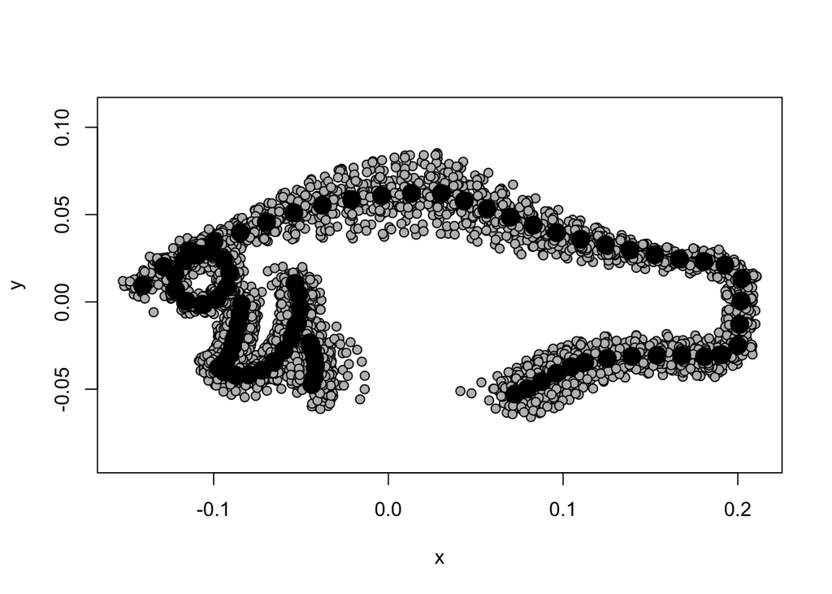

```r
library(StereoMorph)

shapes <- readShapes("Data/example.digitized")
shapesGM <- readland.shapes(shapes,
  nCurvePts = c(12, 12, 12, 8, 6, 6, 6, 12, 10))

Y.gpa <- gpagen(shapesGM, print.progress = FALSE)
plot(Y.gpa)
```

## **Example 3: Points, Curves and Surfaces**

```r
data(scallops)
scallops$surfslide
```

```
##       [,1]
##  [1,]   17
##  [2,]   18
##  [3,]   19
##  [4,]   20
##  [5,]   21
##  [6,]   22
##  [7,]   23
##  [8,]   24
##  [9,]   25
## [10,]   26
## [11,]   27
## [12,]   28
## [13,]   29
## [14,]   30
```

[output cut: 16 more lines]

```r
#Using Procrustes Distance for sliding
gpa.scallop <- gpagen(A=scallops$coorddata, curves=scallops$curvslide, surfaces=scallops$surfslide, print.progress = F)
plot(gpa.scallop)
```

[output not shown]

# Comments on curves matrices

How does one generate matrices for the `curves` argument in `gpagen`? There are a couple of options.

1. Manually. Once the format is understood, making matrices ‘by hand’ is possible.
2. `define.sliders`. This is an interactive geomorph function with several options. The help file nicely explains how to use this function.
3. `readland.shape`. When digitizing with `StereoMorph` and reading in the data with `readland.shapes`, a curves matrix is auto-generated, based on the number of semilandmarks prescribed.